# Portfolio Report 4: Vectorization and parallel computing

## Parallelize using `foreach`

`foreach` seems a little like a `for` loop. However `foreach` uses binary operators `%do%` and `%dopar%`, and also returns a list as output. It’s useful to use `foreach` with `%do%` to evaluate an expression sequentially and store all outputs in a data struture — by default this is a list but the behavior can be changed using the argument `.combine`.

```r
library(foreach)

# run sequentially using %do%
foreach(i=1:3) %do% {i*i}
```

```
## [[1]]
## [1] 1
##
## [[2]]
## [1] 4
##
## [[3]]
## [1] 9
```

```r
# change output to vector
foreach(i=1:3, .combine="c") %do% {i*i}
```

```
## [1] 1 4 9
```

The above functions use the operator `%do%` and therefore run sequentially. If we simply replace the operator with `%dopar%` R will run the computations in parallel. The above computations are so simple that it’s probably not worth implementing them in parallel. Let’s look at a little example using Markov chain Monte Carlo, in which we may want to run multiple chains to test for pseudo-convergence. All of the parallelization is in the `simulate.chains` function. Note that in order to run the computations in parallel we must register the parallel backend using `registerDoParallel(<cores>)` before `foreach`. When we are finished we should run `stopImplicitCluster()`.

```r
# returns the transition kernel P(x)
make.metropolis.hastings.kernel <- function(pi, Q) {
  q <- Q$density
  P <- function(x) {
      z <- Q$sample(x)
      alpha <- min(1, pi(z) * q(z, x) / pi(x) / q(x, z))
      if(runif(1) < alpha) {
        return(z)
      } else {
        return(x)
      }
  }
  return(P)
}

make.normal.proposal <- function(sigma) {
  Q <- list()
  Q$sample <- function(x) {
    return(rnorm(length(x), x, sigma))
  }
  Q$density <- function(x, z) {
    return(dnorm(z, x, sigma))
  }
  return(Q)
}

simulate.chains <- function(P, x0, n, n.chains, n.cores = 4) {
  # parallelize chains
  registerDoParallel(n.cores)
  simulations <- foreach(i=1:n.chains, .combine="rbind") %dopar% {
    x <- x0[i]
    foreach(i=1:n, .combine="c") %do% {P(x)}
  }
  stopImplicitCluster()
  return(simulations)
}
```

Below we sample from a mixture distribution: The weighted mixture of two normal distributions ${Z \sim 0.6X + 0.4Y}$, where $X \sim N(-2,1)$, $Y \sim N(5, 2^2)$. We use a $N(0,1)$ proposal distribution. We will run $4$ chains in parallel and test for pseudo-convergence by looking at the trace of the chains. Each chain is initialized using a $U[-10,10]$ distribution.

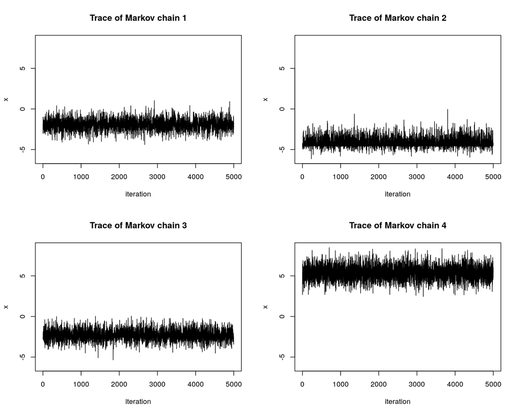

```r
# generate markov chain using MH algorithm
# target: mixture of two normals
n <- 5e3; set.seed(123)
target <- function(x) {0.6*dnorm(x, -2, 1) + 0.4*dnorm(x, 5, 2)}
xs <- simulate.chains(make.metropolis.hastings.kernel(target, make.normal.proposal(1)),
                      runif(4,-10,10), n, 4)

# setup plot space
par(mfrow=c(2,2))

# plot the chains
ylimits <- c(min(xs), max(xs))
for(i in 1:4){
  plot(1:n, xs[i,], type = 'l', xlab="iteration", ylim=ylimits,
       ylab="x", main=paste0("Trace of Markov chain ", i))
}
```

We see that the traces do not converge to the same distribution! This tells us that the chains are not fully exploring the state space and thus we must adjust our proposal distribution.